# Your Digest for Tuesday, Jul 25, 2023 11:59 PM

## Classification of hypertensive disorders during pregnancy

## Risk factors for pregnancy associated hypertensive disorders

Conditions that reduce uteroplacental blood flow

1. "metabolic syndrome like factors"
   1. pre-existing hypertension
   2. DM
   3. OSA
   4. BMI > 30
2. Previous personal history
   1. Previous history of pre-eclampsia or HELLP
3. possible genetic link
   1. first degree relative with gestational hypetension
4. Pregnancy associated factors
   1. First time mother
   2. Twin or higher gestation
5. Thrombophilia
6. Autoimmune disease

## Pathogensis of pregnancy associated hypertensive disorders

> [!TIP] Systemic endthelial dysfunction is key!

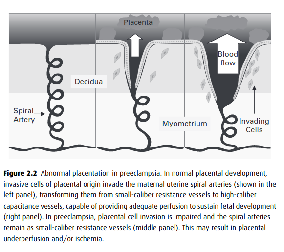

> [Source](https://sci-hub.se/10.1017/CBO9780511902529.004)

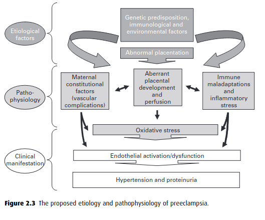

> Current research demonstrates that improper trophoblast differentiation during endothelial invasion due to abnormal regulation and/or production of cytokines, adhesion molecules, major histocompatibility complex molecules, and metalloproteinases plays a key role in the development of a gestational hypertensive disease. Abnormal regulation and/or production of these molecules leads to abnormal development and remodeling of spiral arteries in the deep myometrial tissues. This leads to placental hypoperfusion and ischemia. More recent research shows role of antiangiogenic factors that are released by placental tissue cause systemic endothelial dysfunction which can result in systemic hypertension. (in PIH, activity of angiogenic factors like VEGF and PlGF - *placental growth factor* - are reduced) Organ hypoperfusion from endothelial dysfunction is most commonly seen in the eyes, lungs, liver, kidneys and peripheral vasculature. Overall, most experts agree underlying reason is multifactorial  
> [Source](https://www.ncbi.nlm.nih.gov/books/NBK430839/)

**glomerular endotheliosis is the classic renal lesion of the pre-eclampsia.**

Presents in T3 (3rd trimester), just like HELLP.

> - Establishing a diagnosis
> - Determining the threshold for initiating treatment and the target blood pressure
> - Avoiding drugs with potentially adverse fetal effects
> - Determining the optimum time for delivery

### Pharmacotherapy for hypertension in pregnancy

### Drugs to avoid in pregnancy

Avoid **propranolol** and **other non selective beta blocker** -> can increase uterine irritability. Atenolol has been associated with lower foetal weight. Avoid.  
Avoid **nitroprusside** -> risk of foetal cyanide poisoning.

#### Hydralazine

Oral Hydralazine monotheraphy maintenance therapy should be avoided as it can cause reflex tachycardia.

### Treatment cutoffs

**Severe hypertension**:  
*urgent treatment:*  
if SBP > 160 Or DBP > 110 - confirmed by a second measurement within 15 minutes - should be treated within 60 minutes with *labetalol or hydralzine* to reduce risk of **stroke, heart failure and other complications**.

> Mean arterial pressure should not be reduced by more than 25% over two hours, systolic blood pressure should not be reduced below 130 mmHg, and diastolic blood pressure should not be reduced below 80 mmHg. Blood pressures in the range of 130 to 150/80 to 100 mmHg are ideal. - UpToDate

# Hypertension in the post partum period

Normal physiology : blood pressure decreases immediately after delivery but then increases in a few days and remains elevated above baseline levels.

> Postpartum hypertension may be due to persistence of antepartum or intrapartum hypertension or may be of new onset.  
> "post partum preeclampsia" refers to the *identification of features of preeclampsia* only following delivery. - this happens in around 5% of patients.

## Options for pharmacotherapy in post partum period: (safety in breast feeding)

1. CCBs are **safe**.
2. ACE inhibitors - transferred in breatmilk in low concentrations. *may be risky*
3. Beta blockers : propranolol, metoprolol and labetalol are **safe**.
   1. *Atenolol is transferred in milk and can affect the baby.*
4. HCQ : may reduce milk volume, but safe in low doses.
5. Hydralazine and methyl dopa - safe.

## Hypothyroidism

- **COMMONEST CAUSE of hypothyroidism** in iodine sufficient areas
- chronic automimmune thyroiditis - months to years.
- commoner in late middle aged **women**
- Histology: *lymphocytic and plasma cell infiltration*
- Destruction is cell and antibody mediated.

#### Types of Thyroiditis

| Hashimoto's | De quervain | Post partum | Drug induced | radiation | Infectious | Silent |
| --- | --- | --- | --- | --- | --- | --- |
| chronic autoimmune - months to years | Post viral thyroiditis - **days** | rare, around 6 months post partum, resolves by 12 months PP | Lithium, interferons | radio-iodine therapy | rare, bacterial infection |  |
| **Rubbery gland** | Painful, warm thyroid |  |  |  |  |  |
|  | Transient hyper, then hypothyroidism | Hyper and then hypothyroidism |  |  |  |  |
|  |  | risk factors: type 1 DM and previous episodes |  |  |  |  |

##### Riedels thyroiditis :

[Source](https://www.ncbi.nlm.nih.gov/books/NBK537303/)

fibrous thyroiditis (Reidel's thyroiditis) -> fibrosis of the thyroid gland; woody, hard gland on palpation.

[figure not shown]

In #pregnancy, **thyroxine reqruiremtn increases**.

- Tuberculosis verrucosa cutis : warty lesion; occurs with skin innoculation in an invidual who is partially immune.